#### AlaskaPredicted winner: Dan S. Sullivan (R)

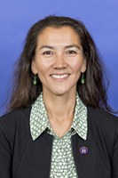

Mary Peltola

Democratic

[figure not shown]

Dan S. Sullivan

Incumbent · Republican

D 37.1%R 62.9%

Including undecided/other: D 26% · R 44% · U 31%

#### AlabamaPredicted winner: Barry Moore (R)

EW

Everett Wess

Democratic

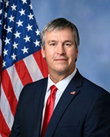

Barry Moore

Republican

D 36.6%R 63.4%

Including undecided/other: D 26% · R 44% · U 30%

#### ArkansasPredicted winner: Tom Cotton (R)

HS

Hallie Shoffner

Democratic

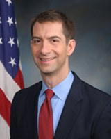

Tom Cotton

Incumbent · Republican

D 39.4%R 60.6%

Including undecided/other: D 29% · R 44% · U 27%

#### ColoradoPredicted winner: John Hickenlooper (D)

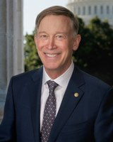

John Hickenlooper

Incumbent · Democratic

MB

Mark Baisley

Republican

D 59.5%R 40.5%

Including undecided/other: D 46% · R 31% · U 23%

#### DelawarePredicted winner: Chris Coons (D)

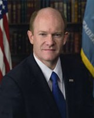

Chris Coons

Incumbent · Democratic

MK

Michael Katz

Republican

D 63.9%R 36.1%

Including undecided/other: D 49% · R 27% · U 24%

#### FloridaPredicted winner: Angie Nixon (D)

AN

Angie Nixon

Democratic

[figure not shown]

Ashley Moody

Incumbent · Republican

D 54.4%R 45.6%

Including undecided/other: D 41% · R 34% · U 25%

#### GeorgiaPredicted winner: Mike Collins (R)

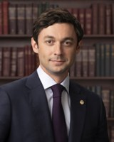

Jon Ossoff

Incumbent · Democratic

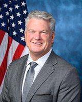

Mike Collins

Republican

D 46.5%R 53.5%

Including undecided/other: D 32% · R 37% · U 31%

#### IowaPredicted winner: Ashley Hinson (R)

JT

Josh Turek

Democratic

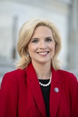

Ashley Hinson

Republican

D 38.9%R 61.1%

Including undecided/other: D 29% · R 45% · U 26%

#### IdahoPredicted winner: Jim Risch (R)

?

No Democratic nominee

Democratic

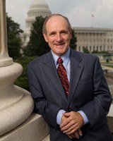

Jim Risch

Incumbent · Republican

D 32.4%R 67.6%

Including undecided/other: D 24% · R 50% · U 26%

independent: Todd Achilles

#### IllinoisPredicted winner: Juliana Stratton (D)

JS

Juliana Stratton

Democratic

DT

Don Tracy

Republican

D 61.2%R 38.8%

Including undecided/other: D 46% · R 29% · U 25%

#### KansasPredicted winner: Roger Marshall (R)

AH

Adam Hamilton

Democratic

[figure not shown]

Roger Marshall

Incumbent · Republican

D 42.8%R 57.2%

Including undecided/other: D 32% · R 42% · U 26%

#### KentuckyPredicted winner: Andy Barr (R)

CB

Charles Booker

Democratic

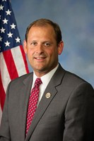

Andy Barr

Republican

D 34.7%R 65.3%

Including undecided/other: D 25% · R 48% · U 27%

#### LouisianaPredicted winner: Julia Letlow (R)

JD

Jamie Davis

Democratic

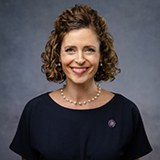

Julia Letlow

Republican

D 37.6%R 62.4%

Including undecided/other: D 26% · R 43% · U 31%

#### MassachusettsPredicted winner: Ed Markey (D)

[figure not shown]

Ed Markey

Incumbent · Democratic

JD

John Deaton

Republican

D 71.8%R 28.2%

Including undecided/other: D 56% · R 22% · U 21%

#### MainePredicted winner: Troy Jackson (D)

TJ

Troy Jackson

Democratic

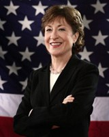

Susan Collins

Incumbent · Republican

D 58.7%R 41.3%

Including undecided/other: D 49% · R 34% · U 17%

#### MichiganPredicted winner: Mike Rogers (R)

AE

Abdul El-Sayed

Democratic

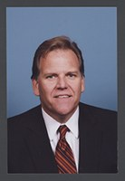

Mike Rogers

Republican

D 49.5%R 50.5%

Including undecided/other: D 37% · R 38% · U 25%

#### MinnesotaPredicted winner: Peggy Flanagan (D)

PF

Peggy Flanagan

Democratic

MT

Michele Tafoya

Republican

D 56.3%R 43.7%

Including undecided/other: D 44% · R 34% · U 22%

#### MississippiPredicted winner: Cindy Hyde-Smith (R)

SC

Scott Colom

Democratic

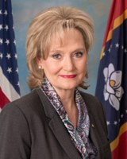

Cindy Hyde-Smith

Incumbent · Republican

D 36.8%R 63.2%

Including undecided/other: D 25% · R 43% · U 31%

#### MontanaPredicted winner: Kurt Alme (R)

AB

Alani Bankhead

Democratic

KA

Kurt Alme

Republican

D 43.8%R 56.2%

Including undecided/other: D 34% · R 44% · U 21%

#### North CarolinaPredicted winner: Roy Cooper (D)

RC

Roy Cooper

Democratic

MW

Michael Whatley

Republican

D 52.6%R 47.4%

Including undecided/other: D 40% · R 36% · U 24%

#### NebraskaPredicted winner: Pete Ricketts (R)

?

No Democratic nominee

Democratic

[figure not shown]

Pete Ricketts

Incumbent · Republican

D 35.5%R 64.5%

Including undecided/other: D 26% · R 47% · U 28%

independent: Dan Osborn

#### New HampshirePredicted winner: Chris Pappas (D)

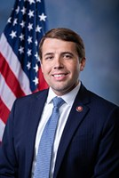

Chris Pappas

Democratic

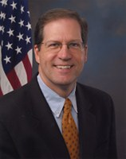

John E. Sununu

Republican

D 61.9%R 38.1%

Including undecided/other: D 50% · R 31% · U 19%

#### New JerseyPredicted winner: Cory Booker (D)

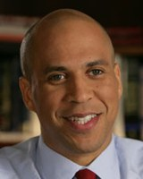

Cory Booker

Incumbent · Democratic

JM

Justin Murphy

Republican

D 64.4%R 35.6%

Including undecided/other: D 48% · R 27% · U 25%

#### New MexicoPredicted winner: Ben Ray Luján (D)

[figure not shown]

Ben Ray Luján

Incumbent · Democratic

LM

Larry Marker

Republican

D 68.2%R 31.8%

Including undecided/other: D 50% · R 23% · U 26%

#### OhioPredicted winner: Jon Husted (R)

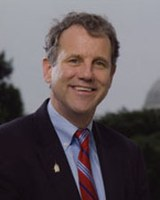

Sherrod Brown

Democratic

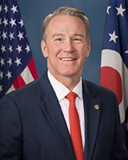

Jon Husted

Incumbent · Republican

D 42.4%R 57.6%

Including undecided/other: D 31% · R 43% · U 26%

#### OklahomaPredicted winner: Kevin Hern (R)

NT

N'Kiyla "Jasmine" Thomas

Democratic

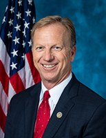

Kevin Hern

Republican

D 37.3%R 62.7%

Including undecided/other: D 26% · R 43% · U 31%

#### OregonPredicted winner: Jeff Merkley (D)

[figure not shown]

Jeff Merkley

Incumbent · Democratic

DS

David Brock Smith

Republican

D 59.7%R 40.3%

Including undecided/other: D 46% · R 31% · U 23%

#### Rhode IslandPredicted winner: Jack Reed (D)

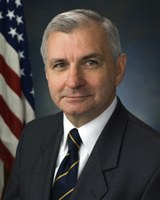

Jack Reed

Incumbent · Democratic

RM

Raymond McKay

Republican

D 62.6%R 37.4%

Including undecided/other: D 46% · R 28% · U 26%

#### South CarolinaPredicted winner: Darline Graham (R)

AA

Annie Andrews

Democratic

DG

Darline Graham

Incumbent · Republican

D 44.0%R 56.0%

Including undecided/other: D 32% · R 41% · U 27%

#### South DakotaPredicted winner: Mike Rounds (R)

?

No Democratic nominee

Democratic

[figure not shown]

Mike Rounds

Incumbent · Republican

D 31.4%R 68.6%

Including undecided/other: D 23% · R 51% · U 26%

independent: Brian Bengs

#### TennesseePredicted winner: Bill Hagerty (R)

MB

Marquita Bradshaw

Democratic

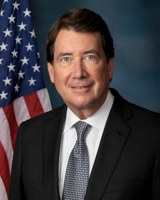

Bill Hagerty

Incumbent · Republican

D 38.6%R 61.4%

Including undecided/other: D 28% · R 45% · U 27%

#### TexasPredicted winner: Ken Paxton (R)

JT

James Talarico

Democratic

KP

Ken Paxton

Republican

D 48.0%R 52.0%

Including undecided/other: D 32% · R 34% · U 34%

#### VirginiaPredicted winner: Mark Warner (D)

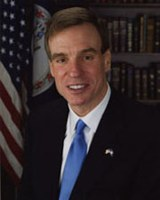

Mark Warner

Incumbent · Democratic

BM

Bert Mizusawa

Republican

D 56.3%R 43.7%

Including undecided/other: D 41% · R 32% · U 27%

#### West VirginiaPredicted winner: Shelley Moore Capito (R)

RA

Rachel Fetty Anderson

Democratic

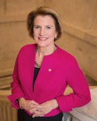

Shelley Moore Capito

Incumbent · Republican

D 30.6%R 69.4%

Including undecided/other: D 23% · R 53% · U 24%

#### WyomingPredicted winner: Harriet Hageman (R)

JB

James W. Byrd

Democratic

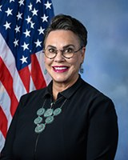

Harriet Hageman

Republican

D 30.8%R 69.2%

Including undecided/other: D 24% · R 53% · U 23%